# Probset performance measurements on slide 0020227

This is a slide that was run in December 2023. The slide includes one section from the same block (the “good” block) done with the limited library on 0010972 that gave some decent data. One triangular piece is a scleroderma lung. The goal of this analysis is to look at components of probeset behavior and whether that can be predicted from single cell sequencing from reference datasets.

# Environment

```r
library(Seurat)
library(tidyverse)
```

## Read in Xenium

```r
ipf3.xen <- LoadXenium('output-XETG00143__0020227__Region_1__20231214__022306')
```

[output not shown]

## Read in IPF Cell Atlas GSE136831

```r
original.dir <- ('~/vcalab-files/datasets/GSE136831_IPF_Cell_Atlas/')
metadata <- read_tsv(paste0(original.dir,'GSE136831_AllCells.Samples.CellType.MetadataTable.txt.gz'))
metadata <- as.data.frame(metadata)
rownames(metadata) <- metadata$CellBarcode_Identity

features <- read_tsv(paste0(original.dir,'GSE136831_AllCells.GeneIDs.txt.gz'))
cells <- read_tsv(paste0(original.dir,'GSE136831_AllCells.cellBarcodes.txt.gz'), col_names = F)
counts <- Matrix::readMM(paste0(original.dir,'GSE136831_RawCounts_Sparse.mtx.gz'))
rownames(counts) <- features$HGNC_EnsemblAlt_GeneID
colnames(counts) <- cells$X1
```

```r
ipfatlas.cells <- CreateSeuratObject(counts=counts, meta.data=metadata)
```

```r
rm(counts,cells,features,metadata)
gc()
```

```
             used   (Mb) gc trigger    (Mb)   max used    (Mb)
Ncells   33536809 1791.1  107191045  5724.7  107191045  5724.7
Vcells 1151679731 8786.7 3672578053 28019.6 4293005269 32753.1
```

## Normalize both datasets

```r
ipf3.xen <- NormalizeData(ipf3.xen)
```

```
Normalizing layer: counts
```

```r
ipfatlas.cells <- NormalizeData(ipfatlas.cells)
```

```
Normalizing layer: counts
```

## Filter xenium dataset

In this iteration of this analysis, will do some base filtering of the dataset. Many cells had essentially zero or few counts, these cells are noise and I think realistically those cells are lost to us; so we should evaluate probeset performance in cells that actually returned reasonable data.

```r
ipf3.xen <- subset(ipf3.xen, subset=nCount_Xenium>20 & nFeature_Xenium>4)
```

# Comparison of raw counts between scRNA and Xenium

```r
# limit analysis to probes that can be assessed
probes <- intersect(rownames(ipf3.xen), rownames(ipfatlas.cells))
```

```r
# Enable parallel processing - seurat does not play nice with parallel so all seurat processing should ideally be single-core
library(future)
plan(multisession, workers=6)
options(future.globals.maxSize = 104857600000000)
library(future.apply)
```

## Zero-suppressed average expression

```r
nonzeroaverages <- data.frame(gene=probes,
                              xeniumAvg=unlist(future_lapply(probes, function(symbol){
                                counts <- ipf3.xen[['Xenium']]$counts[symbol,]
                                nonzeroavg <- mean(counts[counts!=0])
                                return(nonzeroavg)
                                })),
                              ipfatlasAvg=unlist(future_lapply(probes, function(symbol){
                                counts <- ipfatlas.cells[['RNA']]$counts[symbol,]
                                nonzeroavg <- mean(counts[counts!=0])
                                return(nonzeroavg)
                              }))
)
```

[output not shown]

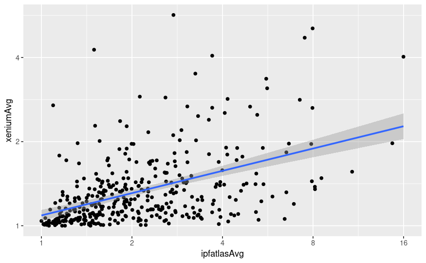

```r
ggplot(data=nonzeroaverages, aes(x=ipfatlasAvg, y=xeniumAvg)) +
  geom_point() +
  scale_x_continuous(trans='log2') +
  scale_y_continuous(trans='log2') +
  geom_smooth(method='lm', formula= y~x)
```

Probes with much lower Xenium average than we would expect based on expression.

```r
lm(xeniumAvg~ipfatlasAvg, data=nonzeroaverages)
```

```
Call:
lm(formula = xeniumAvg ~ ipfatlasAvg, data = nonzeroaverages)

Coefficients:
(Intercept)  ipfatlasAvg
     1.0499       0.1411
```

Somewhat arbitrarily, let’s say something is somewhat lower expression than we would expect, that would not be great.

```r
folddiff <- 4
nonzeroaverages$shitlist1 <- unlist(lapply(nonzeroaverages$gene, function(symbol){
  expected <- (0.09528 /folddiff) * filter(nonzeroaverages,gene==symbol)$ipfatlasAvg + 1
  return(filter(nonzeroaverages,gene==symbol)$xeniumAvg < expected)
}))
```

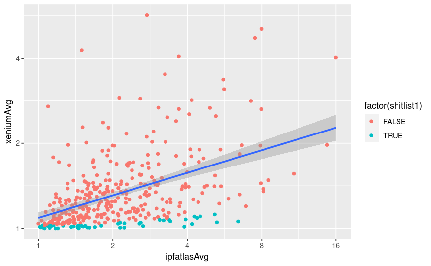

```r
ggplot(data=nonzeroaverages, aes(x=ipfatlasAvg, y=xeniumAvg)) +
  geom_point(aes(color=factor(shitlist1))) +
  scale_x_continuous(trans='log2') +
  scale_y_continuous(trans='log2') +
  geom_smooth(method='lm', formula= y~x)
```

```r
filter(nonzeroaverages, shitlist1)
```

| gene | xeniumAvg | ipfatlasAvg | shitlist1 |
| --- | --- | --- | --- |
| ARG1 | 1.004505 | 1.109474 | TRUE |
| ARL14 | 1.027027 | 1.150538 | TRUE |
| ASCL1 | 1.018405 | 2.652174 | TRUE |
| ASCL2 | 1.018949 | 1.108058 | TRUE |
| ASCL3 | 1.013800 | 3.888889 | TRUE |
| CCR3 | 1.014778 | 1.107388 | TRUE |
| CD70 | 1.000000 | 1.455546 | TRUE |
| CDKN2A | 1.020441 | 1.546578 | TRUE |
| CLC | 1.015873 | 1.388027 | TRUE |
| CLCA1 | 1.008130 | 1.023404 | TRUE |

[output cut: 43 more lines]

## Zero-suppressed median expression

```r
nonzeromedians <- data.frame(gene=probes,
                              xeniumMed=unlist(future_lapply(probes, function(symbol){
                                counts <- ipf3.xen[['Xenium']]$counts[symbol,]
                                nonzeroavg <- median(counts[counts!=0])
                                return(nonzeroavg)
                                })),
                              ipfatlasMed=unlist(future_lapply(probes, function(symbol){
                                counts <- ipfatlas.cells[['RNA']]$counts[symbol,]
                                nonzeroavg <- median(counts[counts!=0])
                                return(nonzeroavg)
                              }))
)
```

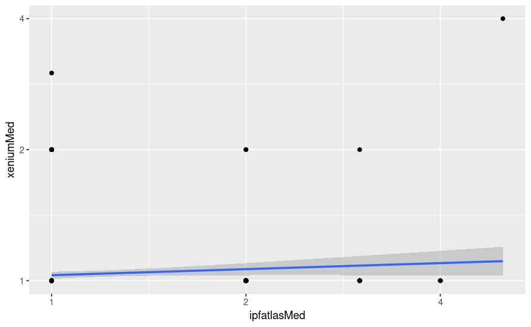

```r
ggplot(data=nonzeromedians, aes(x=ipfatlasMed, y=xeniumMed)) +
  geom_point() +
  scale_x_continuous(trans='log2') +
  scale_y_continuous(trans='log2') +
  geom_smooth(method='lm', formula= y~x)
```

## zero-suppressed top decile expression

```r
nonzerodecile <- data.frame(gene=probes,
                              xeniumDec=unlist(future_lapply(probes, function(symbol){
                                counts <- ipf3.xen[['Xenium']]$counts[symbol,]
                                nonzeroDec <- quantile(counts[counts!=0], probs=0.9)
                                return(nonzeroDec)
                                })),
                              ipfatlasDec=unlist(future_lapply(probes, function(symbol){
                                counts <- ipfatlas.cells[['RNA']]$counts[symbol,]
                                nonzeroDec <- quantile(counts[counts!=0], probs=0.9)
                                return(nonzeroDec)
                              }))
)
```

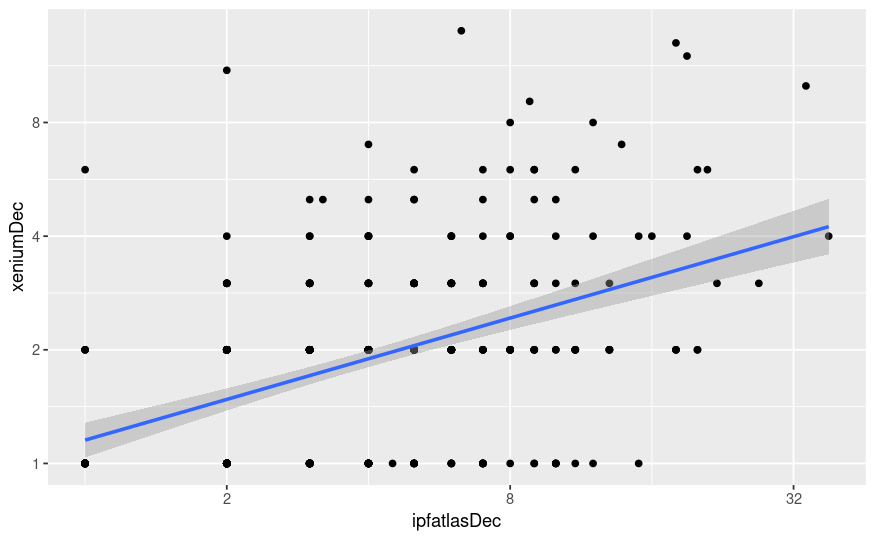

```r
ggplot(data=nonzerodecile, aes(x=ipfatlasDec, y=xeniumDec)) +
  geom_point() +
  scale_x_continuous(trans='log2') +
  scale_y_continuous(trans='log2') +
  geom_smooth(method='lm', formula= y~x)
```

# Comparison of normalized counts between scRNA and Xenium

This might better account for cells wtih low overall detection, and also has the advantage of being somewhat closer to what actual analysis might be like.

## Zero-suppressed average normalized expression

```r
nonzeroaverages$xeniumNormAvg <- unlist(future_lapply(probes, function(symbol){
  counts <- GetAssayData(object = ipf3.xen, slot = 'data')[symbol,]
  nonzeroavg <- mean(counts[counts>0])
  return(nonzeroavg)
}))
nonzeroaverages$ipfatlasNormAvg <- unlist(future_lapply(probes, function(symbol){
  counts <- GetAssayData(object = ipfatlas.cells, slot = 'data')[symbol,]
  nonzeroavg <- mean(counts[counts>0])
  return(nonzeroavg)
}))
```

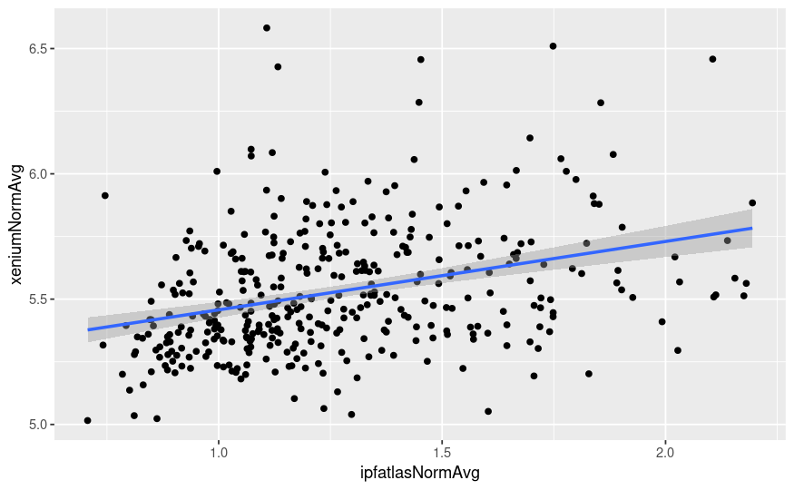

```r
ggplot(data=nonzeroaverages, aes(x=ipfatlasNormAvg, y=xeniumNormAvg)) +
  geom_point() +
  geom_smooth(method='lm', formula= y~x)
```

Probes with much lower Xenium average than we would expect based on expression.

```r
lm(xeniumNormAvg ~ ipfatlasNormAvg, data = nonzeroaverages)
```

```
Call:
lm(formula = xeniumNormAvg ~ ipfatlasNormAvg, data = nonzeroaverages)

Coefficients:
    (Intercept)  ipfatlasNormAvg
         5.1843           0.2729
```

Somewhat arbitrarily, let’s say something is some-fold lower normalized expression than we would expect, that would not be great.

```r
logdiff <- .6
nonzeroaverages$shitlist2 <- unlist(lapply(nonzeroaverages$gene, function(symbol){
  expected <- 0.3421 * filter(nonzeroaverages,gene==symbol)$ipfatlasNormAvg + 5.6541 - logdiff
  return(filter(nonzeroaverages,gene==symbol)$xeniumNormAvg < expected)
}))
```

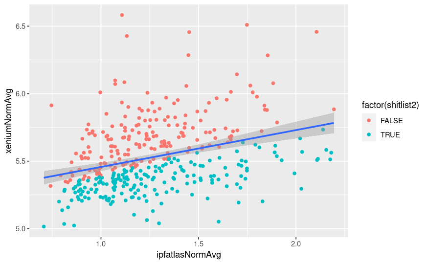

```r
ggplot(data=nonzeroaverages, aes(x=ipfatlasNormAvg, y=xeniumNormAvg)) +
  geom_point(aes(color=factor(shitlist2))) +
  geom_smooth(method='lm', formula= y~x)
```

```r
filter(nonzeroaverages, shitlist2)
```

| gene | xeniumAvg | ipfatlasAvg | shitlist1 | xeniumNormAvg | ipfatlasNormAvg | shitlist2 |
| --- | --- | --- | --- | --- | --- | --- |
| ACE2 | 1.042336 | 1.059160 | FALSE | 5.234863 | 0.8803703 | TRUE |
| ADAM17 | 1.268741 | 3.409526 | FALSE | 5.391724 | 1.5797529 | TRUE |
| ADAM28 | 1.175732 | 2.439412 | FALSE | 5.474668 | 1.4801780 | TRUE |
| AGER | 1.230827 | 3.743683 | FALSE | 5.389321 | 1.4426117 | TRUE |
| AGR2 | 1.797311 | 4.149697 | FALSE | 5.477600 | 1.3324659 | TRUE |
| AGR3 | 1.408593 | 5.151288 | FALSE | 5.451103 | 1.6370200 | TRUE |
| AQP9 | 1.381116 | 1.574683 | FALSE | 5.315253 | 1.1149658 | TRUE |
| AREG | 1.830715 | 6.522397 | FALSE | 5.568605 | 2.0313897 | TRUE |
| ARG1 | 1.004505 | 1.109474 | TRUE | 5.332644 | 1.0114252 | TRUE |
| ARNT | 1.040091 | 1.205956 | FALSE | 5.340507 | 0.9899305 | TRUE |

[output cut: 172 more lines]

## Mix and match

SPARPOS is going to want to filter on norm avg expression. So does that clearly predict whether raw counts are found in Xenium?

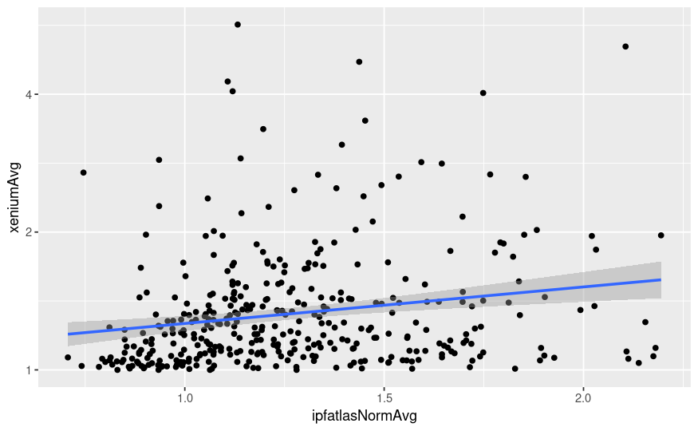

```r
ggplot(data=nonzeroaverages, aes(x=ipfatlasNormAvg, y=xeniumAvg)) +
  geom_point() +
  scale_y_continuous(trans='log2') +
  geom_smooth(method='lm', formula= y~x)
```

I think the answer is, sort of. But really the conclusion seems to be that there are high-performing probes that aren’t as sensitive to low expression, assuming they are specific.

```r
xenrawthreshold <- 1.5
nonzeroaverages$winner1 <- unlist(lapply(nonzeroaverages$gene, function(symbol){
  return(filter(nonzeroaverages,gene==symbol)$xeniumAvg > xenrawthreshold)
}))
```

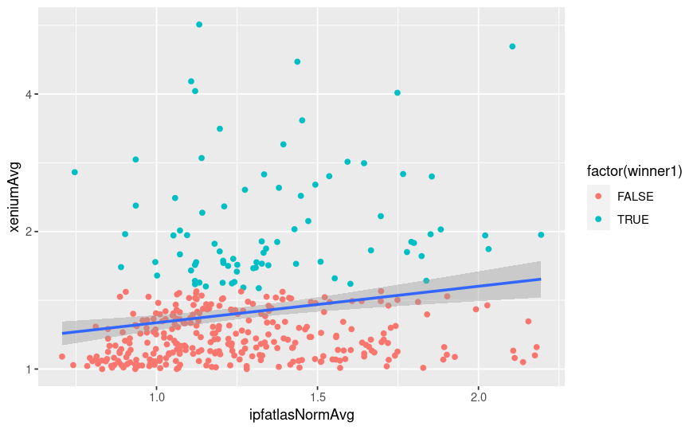

```r
ggplot(data=nonzeroaverages, aes(x=ipfatlasNormAvg, y=xeniumAvg)) +
  geom_point(aes(color=factor(winner1))) +
  scale_y_continuous(trans='log2') +
  geom_smooth(method='lm', formula= y~x)
```

```r
filter(nonzeroaverages, winner1)
```

[output not shown]

# Identify genes in filtered xenium that are informative/variable

```r
ipf3.xen <- FindVariableFeatures(ipf3.xen, verbose=F,
                                 dispersion.cutoff = 1.2)
```

[output not shown]

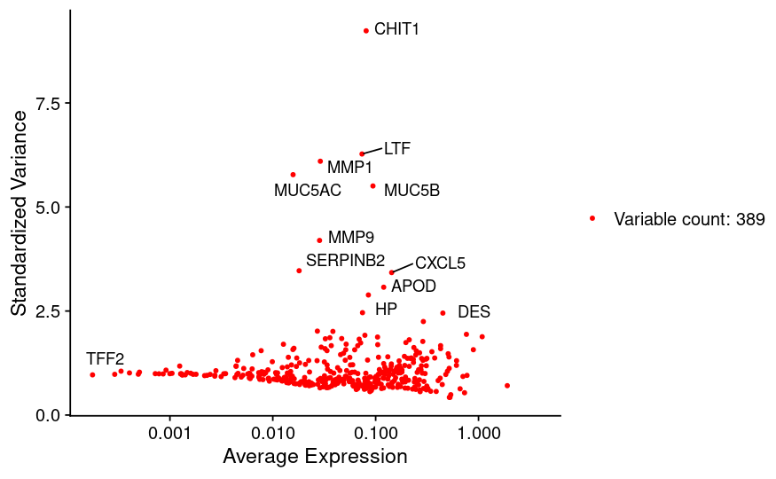

```r
p <- VariableFeaturePlot(ipf3.xen)
LabelPoints(plot = p, points = rownames(ipf3.xen), repel = TRUE)
```

## merge to one table and export

```r
xeniumvariances <- HVFInfo(ipf3.xen)[VariableFeatures(ipf3.xen), ] %>%
  select(variance.standardized)
xeniumvariances$gene <- rownames(xeniumvariances)
xeniumvariances <- as_tibble(xeniumvariances)
xeniumvariances
```

| variance.standardized | gene |
| --- | --- |
| 9.2331170 | CHIT1 |
| 6.2729896 | LTF |
| 6.0989125 | MMP1 |
| 5.7765195 | MUC5AC |
| 5.5046746 | MUC5B |
| 4.1954639 | MMP9 |
| 3.4678714 | SERPINB2 |
| 3.4231154 | CXCL5 |
| 3.0715076 | APOD |
| 2.8850603 | HP |

[output cut: 379 more lines]

```r
NA
```

```r
# kludging to merge
scratch2 <- full_join(nonzeroaverages, xeniumvariances, by='gene')
scratch2
```

| gene | xeniumAvg | ipfatlasAvg | shitlist1 | xeniumNormAvg | ipfatlasNormAvg | shitlist2 | winner1 | variance.standardized |
| --- | --- | --- | --- | --- | --- | --- | --- | --- |
| ABCA3 | 2.896821 | 2.123743 | FALSE | 5.901605 | 1.1400009 | FALSE | TRUE | 1.3954188 |
| ACE | 1.475693 | 1.384910 | FALSE | 5.666253 | 0.9044732 | FALSE | FALSE | 1.1350106 |
| ACE2 | 1.042336 | 1.059160 | FALSE | 5.234863 | 0.8803703 | TRUE | FALSE | 0.8714466 |
| ACKR1 | 1.442534 | 7.928837 | FALSE | 5.786917 | 1.9029647 | FALSE | FALSE | 1.4858579 |
| ADAM17 | 1.268741 | 3.409526 | FALSE | 5.391724 | 1.5797529 | TRUE | FALSE | 0.8274302 |
| ADAM28 | 1.175732 | 2.439412 | FALSE | 5.474668 | 1.4801780 | TRUE | FALSE | 0.8766824 |
| ADAMTS1 | 1.662271 | 2.295967 | FALSE | 5.889038 | 1.3006259 | FALSE | TRUE | 1.3626960 |
| ADGRL4 | 1.108668 | 2.106438 | FALSE | 5.589348 | 1.2750970 | FALSE | FALSE | 0.8019866 |
| AGER | 1.230827 | 3.743683 | FALSE | 5.389321 | 1.4426117 | TRUE | FALSE | 0.8261801 |
| AGR2 | 1.797311 | 4.149697 | FALSE | 5.477600 | 1.3324659 | TRUE | TRUE | 1.7413618 |

[output cut: 379 more lines]

```r
write.csv(scratch2, file='probesets_xeniumperformance.csv')
```